# concept_3_4

## ECON 0150 | Economic Data Analysis

Building economic models with data.

### *Part 3.4 | The Simplest Linear Model*

## General Linear Model (GLM)

The General Linear Model just draws lines through data points.

We just developed the simplest GLM!

## General Linear Model (GLM)

The General Linear Model just draws lines through data points.

**What is a GLM?**

- Basically just a line drawn through the data.

**Linear Model Equation**: $y = mx + b$

- We call $y$ the ‘outcome variable’ (numerical only in this class)
- We call $x$ the ‘predictor variable’ (categorical or numerical)
- Can have more than one predictor variable: $y = m_1 x_1 + m_2 x_2 + b$
- If you want to be fancy, write it like: $y_i = mx_i + b + \epsilon_i$

## General Linear Model (GLM)

The General Linear Model just draws lines through data points.

**How do we choose the line?**

- We minimize the ‘wrongness’ of the model.

**Mean Squared Error**: $MSE = \frac{1}{n} \sum_i \epsilon_i^2$

- This $\epsilon_i$ is just how wrong our model is for data point $i$
- This is just the average distance between the line and a data point.
- This is very similar to *Variance*!

## GLM: Intercept-Only

A model with no x ( basically: x=0 ).

The simplest GLM is using only an intercept term: $y=b$.

- The data $x_i$ is in blue.
- The model $b$ is in red.
- The error $\epsilon_i$ is in green.

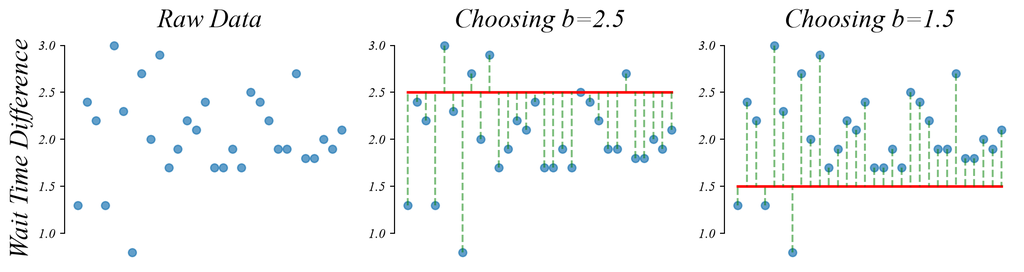

*> what should we choose for b to minimize the model’s error?*

## Exercise 3.4 | Exploring the Data

Open Exercise 3.4 and complete Questions 1-2.

Load the data and compute summary statistics.

```python
data['wait_difference'].mean()
data['wait_difference'].std()
```

Make a histogram of the wait time differences.

```python
sns.histplot(x='wait_difference', data=data)
```

*> are the values centered near zero?*

## Exercise 3.4 | Computing MSE

Complete Questions 3-5. Which value of $b$ minimizes the model’s error?

Compute the MSE for $b = 2.5$, $b = 1.5$, and $b = \bar{y}$.

```python
b = 2.5
np.mean((data['wait_difference'] - b)**2)
```

```python
b = 1.5
np.mean((data['wait_difference'] - b)**2)
```

```python
b = data['wait_difference'].mean()
np.mean((data['wait_difference'] - b)**2)
```

*> which value of $b$ gives the smallest MSE?*

## GLM: Line Fitting and the Sample Mean

The sample mean minimizes the MSE.

We minimize the MSE by choosing $b$ to be equal to the sample mean $\bar{y}$.

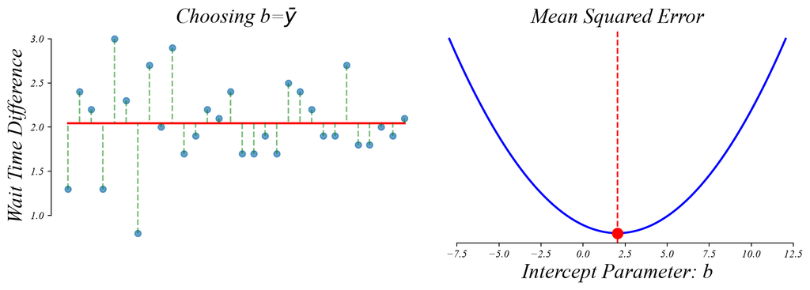

*> when we’ve minimized MSE, it’s equal to the Variance!*

## GLM: Sampling Error and Line Fitting

Like before, if we take many samples, we get slightly different means and slightly different fits.

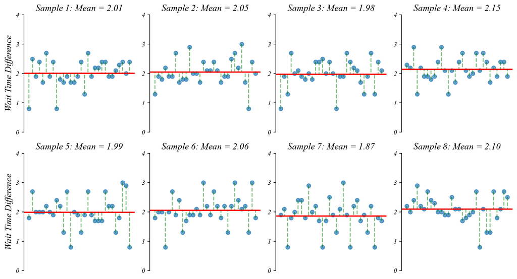

## GLM: Distribution Around the Sample Mean

The intercept terms follow a t-distribution centered on the true mean.

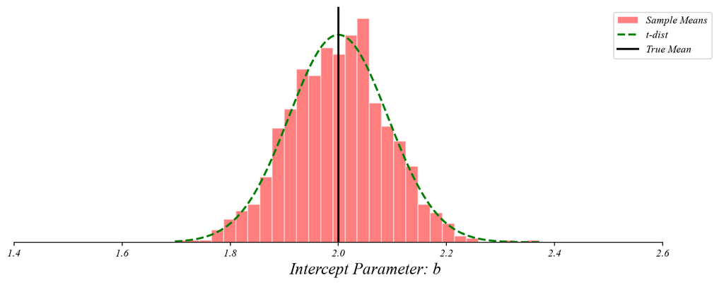

*> we only observe one sample mean, so we center the distribution there*

## GLM: Distribution Around the Sample Mean

We center the sampling distribution on our observed sample mean.

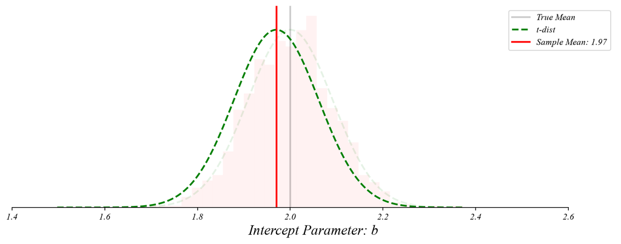

*> what is the probability of seeing this if the average wait time is 1.8 minutes?*

## GLM: Finding p-values

The probability of something as extreme as our sample mean given the null.

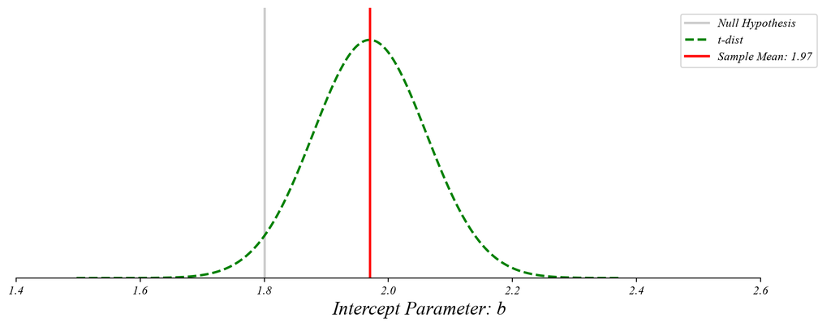

*> here we’re centering the t-distribution on the observed sample mean*

*> as before, this is mathematically equivalent to centering on the null*

## GLM: Finding p-values

The probability of something as extreme as our sample mean given the null.

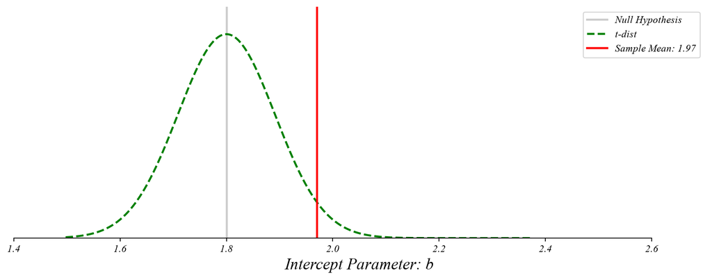

## GLM: Finding p-values

The probability of something as extreme as our sample mean given the null.

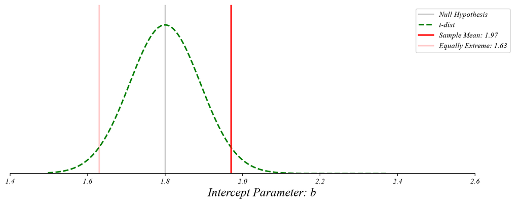

## GLM: Finding p-values

The probability of something as extreme as our sample mean given the null.

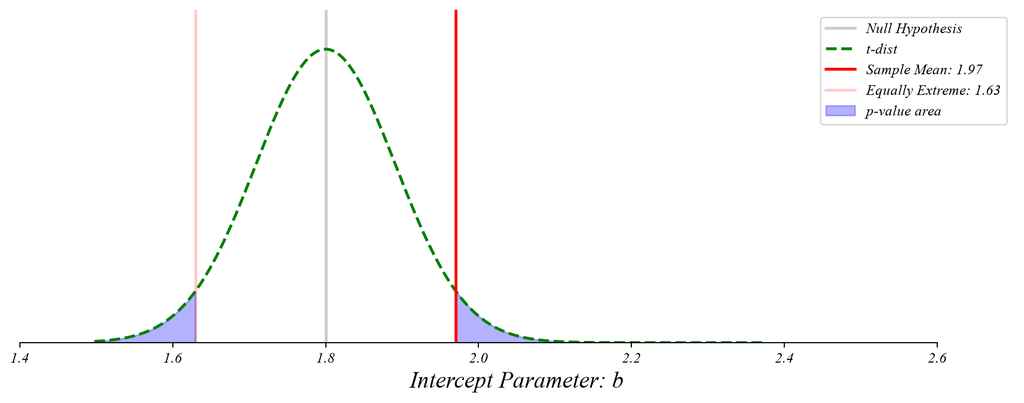

## GLM: Intercept Model

A t-test is a linear model with only an intercept: $y = \beta_0 + \epsilon$

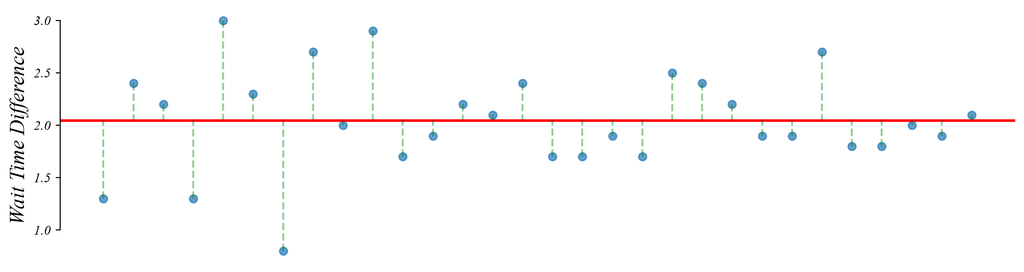

*> the sample mean $\beta_0$ minimizes the sum of squared errors*

*> the p-value tells us the probability of the data given the default null*

*> the best guess of the true mean is $\beta_0$*

*> this is the simplest version of an OLS regression model*

## Exercise 3.4 | Fitting the Model

Complete Questions 6-7. Fit the intercept-only model in Python.

Fit the model $y \sim 1$ and print the coefficient table.

```python
model = smf.ols('wait_difference ~ 1', data=data).fit()
print(model.summary().tables[1])
```

Compare the intercept coefficient to the sample mean from Question 1.

*> the intercept equals the sample mean: the model’s best prediction is $\bar{y}$*

*> what null hypothesis does the p-value test?*

## Looking Forward: Part 4

Bivariate General Linear Model

**In Part 4 we will explore:**

- Part 4.1 | Numerical Predictors
- Part 4.2 | Categorical Predictors
- Part 4.3 | Timeseries Models
- Part 4.4 | Model Diagnostics

*> all built on the same statistical foundation we explored today*